# Datos Comparativos INE

Lorena Rodriguez Chamorro

25 de junio de 2018

## ANÁLISIS DESCRIPTIVO

El salario bruto medio anual en 2014 estaba situado según la nota de prensa del INE en 22.858,17 euros:

```
## [1] 22858.16
```

Si analizamos el salario medio anual por género tenemos que el salario anual de las mujeres se sitúa por encima de los 19.000 euros (19.744,82 según el INE) mientras que el de los hombres supera los 25.000 (25.727,24 fuente INE):

```
## # A tibble: 2 x 2
##   SEXO   promedio
##   <chr>     <dbl>
## 1 HOMBRE   25727.
## 2 MUJER    19745.
```

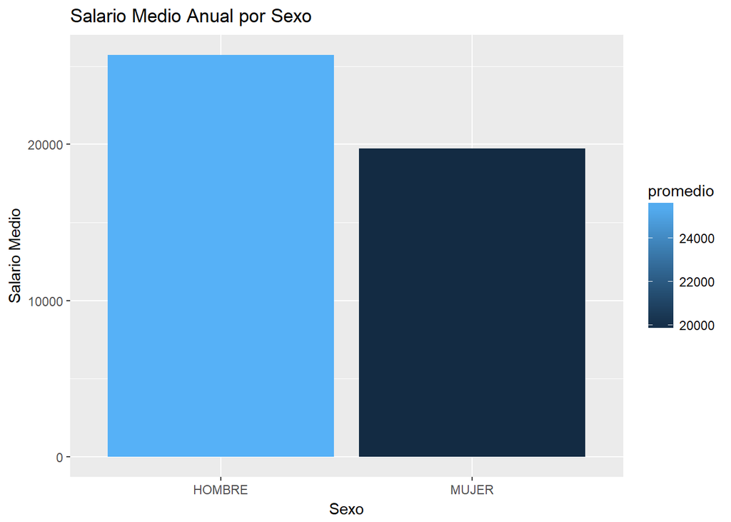

Si estudiamos el salario el salario por el tipo de jornada (tiempo completo o tiempo parcial), tenemos que el salario medio a tiempo parcial es bastante inferior. Los datos publicados por el INE fueron 26.965,35 euros para aquellos trabajadores a tiempo completo frente a 9.794,79 euros para tiempo parcial.

```
## # A tibble: 2 x 2
##   TIPOJOR         promedio
##   <chr>              <dbl>
## 1 TIEMPO COMPLETO   26965.
## 2 TIEMPO PARCIAL     9795.
```

A continuación analizamos el salario por zona geográfica, dónde vemos que la Comunidad de Madrid es la que concentra mayor salario medio mientras que por el contrario los trabajadores de Canarias son los que tienen menor salario medio. Los resultados publicados por el INE están a nivel comunidad autónoma no zona geográfica por lo que no pueden ser comparados.

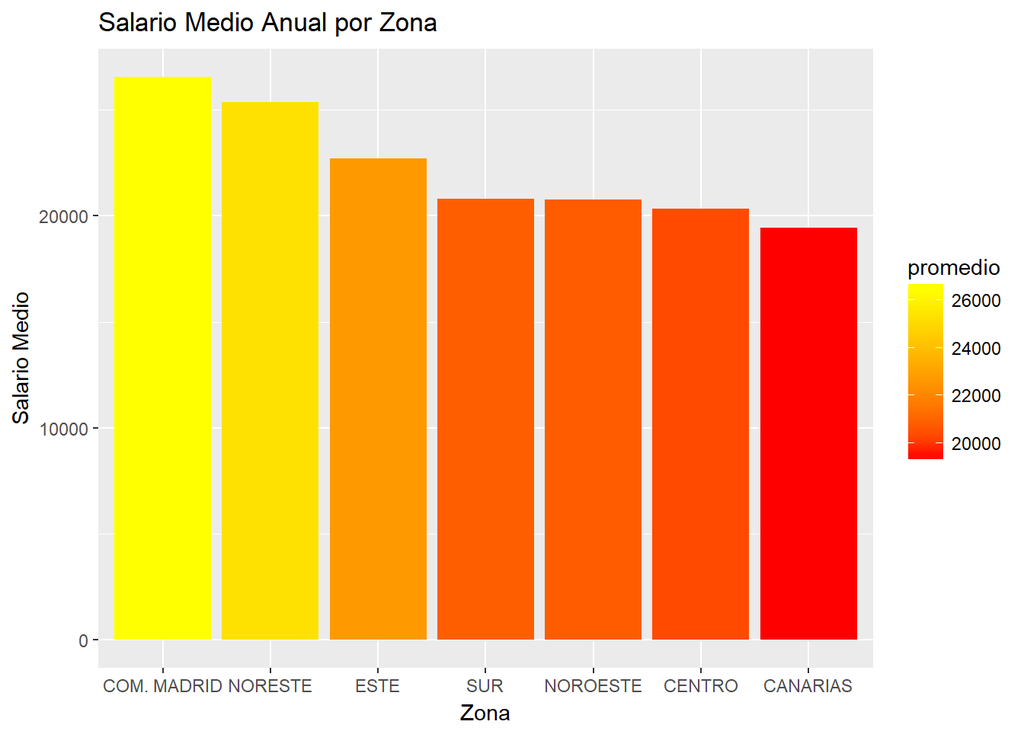

La actividad económica cuyos trabajadores tienen mejor salario medio es Suministro de energía eléctrica, gas, vapor y aire acondicionado (D0 51.034,67 euros según el INE), seguido de Actividades financieras y de seguros (k0).

```
## # A tibble: 2 x 2
##   DES_CNACE                                                       promedio
##   <chr>                                                              <dbl>
## 1 Suministro de energía eléctrica, gas, vapor y aire acondiciona~   51035.
## 2 Actividades financieras y de seguros: servicios financieros, e~   40698.
```

Por otro lado, la actividad económica con menor salario medio es Hostelería (I0 13.636,04 euros por el INE), seguido de Actividades administrativas y servicios auxiliares (N0).

```
## # A tibble: 2 x 2
##   DES_CNACE                                                       promedio
##   <chr>                                                              <dbl>
## 1 Actividades administrativas y servicios auxliares: actividades~   15766.
## 2 Hostelería: servicios de alojamiento, servicios de comidas y b~   13636.
```

El salario medio por tipo de contrato es superior en el caso de duración indefinida, dónde el dato publicado por el INE se sitúa en 24.746,47, mientras que los trabajadores con contrato de duración determinada tienen un salario medio según el INE de 15680,55 euros.

```
## # A tibble: 2 x 2
##   TIPOCON              promedio
##   <chr>                   <dbl>
## 1 DURACION DETERMINADA   15685.
## 2 DURACION INDEFINIDA    24745.
```

Los directores y gerentes (52.512,99) junto con otros técnicos y profesionales científicos e intelectuales son los que mayor salario medio tienen. Además el dato del salario medio de directores y gerentes es el que mayor desviación presenta con los datos publicados por el INE.

```
## # A tibble: 2 x 2
##   DES_TCNO                                                   promedio
##   <chr>                                                         <dbl>
## 1 DIRECTORES Y GERENTES                                        52485.
## 2 OTROS TÉCNICOS Y PROFESIONALES CIENTÍFICOS E INTELECTUALES   37098.
```

Por el contrario,trabajadores de los servicios de restauración y comercio y los trabajadores no cualificados en servicios (12.199,99 euros según INE) son los que menor salario medio tienen.

```
## # A tibble: 2 x 2
##   DES_TCNO                                                 promedio
##   <chr>                                                       <dbl>
## 1 TRABAJADORES DE LOS SERVICIOS DE RESTAURACION Y COMERCIO   14502.
## 2 TRABAJADORES NO CUALIFICADOS EN SERVICIOS                  12200.
```

Además sabíamos que el salario medio se situaba en un

```
## [1] 22858.16
```

Mientras que el salario mediano está en:

```
## (Intercept)
##    19263.78
```

Si analizamos que porcentaje del salario promedio de las mujeres representa sobre el salario medio de los hombres tenemos que :

```
##   porcentaje
## 1   76.74808
```

Para calcular la brecha salarial entre sexos, se tiene que calcular la ganancia por hora, para calcular la diferencia de este cómputo entre hombres y mujeres como porcentaje de la ganancia por hora de los hombres. El resultado de la brecha salarial que proporciona el INE para 2014 se sitúa en un 14%, realizando estos cálculos el resultado que obtengo es:

```
##   promedio
## 1 15.45545
```

A continuación vamos a analizar el salario medio por género, el porcentaje que representa el salario de las mujeres sobre el de los hombres y la diferencia porcentual por las distintas variables, comenzamos por la zona geográfica.

```
##         NUTS1 PROMEDIO_TOT PROMEDIO_H PROMEDIO_M PORCENTAJE DIFERENCIA
## 1         SUR     20820.46   23521.40   17564.37   74.67398   25.32602
## 2     NORESTE     25378.44   28792.03   21525.57   74.76227   25.23773
## 3        ESTE     22707.67   25911.60   19377.06   74.78140   25.21860
## 4    NOROESTE     20786.70   23508.95   17921.70   76.23351   23.76649
## 5 COM. MADRID     26570.35   29734.24   23326.93   78.45140   21.54860
## 6      CENTRO     20341.04   22510.74   17793.09   79.04267   20.95733
## 7    CANARIAS     19436.48   20641.01   18201.97   88.18351   11.81649
```

Dónde podemos observar que es la zona SUR dónde existe mayor diferencia entre el salario medio anual de hombres y mujeres, por el contrario CANARIAS es la zona con menor diferencia, representando el salario medio de las mujeres más del 88% de el de los hombres.

Analizamos las diferencias por Actividad económica:

```
##   DES_CNACE PROMEDIO_TOT PROMEDIO_H PROMEDIO_M PORCENTAJE DIFERENCIA
## 1        B0     32905.60   32054.16   12922.00   40.31300   59.68700
## 2        D0     51034.62   53084.80   21483.17   40.46952   59.53048
```

```
##   DES_CNACE PROMEDIO_TOT PROMEDIO_H PROMEDIO_M PORCENTAJE DIFERENCIA
## 1        G2     16264.78   19279.30   29442.37   152.7150  -52.71498
## 2        I0     13636.05   15368.46   25917.56   168.6412  -68.64120
```

Dónde encontramos que existe mayor diferencia positiva para los hombres en actividades como Industrias extractivas (B0), o Suministro de energía eléctrica, gas, vapor y aire acondicionado (D0). Sin embargo en actividades como Comercio al por mayor y al por menor; reparación de vehículos de motor y motocicletas: comercio al por menor(G2) o Hostelería: servicios de alojamiento, servicios de comidas y bebidas existe una diferencia positiva hacia las mujeres.

Continuamos analizando las posibles diferencias entre género por la variable ocupación, dónde podemos observar que (QO) Ocupaciones Militares es la ocupación con mayor diferencia salarial, (O0) seguida de Trabajadores no cualificados en servicios, por el contrario, (J0) Trabajadores cualificados en el sector agrícola, ganadero, forestal y pesquero es la ocupación que presenta menor diferencia.

```
##    CNO1 PROMEDIO_TOT PROMEDIO_H PROMEDIO_M PORCENTAJE DIFERENCIA
## 1    Q0     15083.78   15310.12   9681.253   63.23433  36.765671
## 2    O0     12199.95   15760.04  10859.715   68.90665  31.093351
## 3    M0     23404.37   25316.79  17763.664   70.16553  29.834469
## 4    L0     22539.49   23194.48  16488.900   71.08975  28.910246
## 5    H0     14971.15   18648.80  13969.919   74.91054  25.089464
## 6    P0     15772.51   16672.95  13050.842   78.27556  21.724442
## 7    E0     20852.89   24147.60  18932.595   78.40364  21.596363
## 8    D0     28238.20   31160.81  24641.672   79.07904  20.920955
## 9    F0     18642.81   21761.91  17252.375   79.27784  20.722165
## 10   G0     14501.67   16633.36  13249.931   79.65877  20.341228
## 11   A0     52485.06   56374.69  45548.513   80.79603  19.203971
## 12   C0     37098.05   40639.10  33028.310   81.27225  18.727748
## 13   I0     25727.46   26347.81  21576.427   81.89078  18.109216
## 14   N0     20131.12   20234.01  17506.920   86.52225  13.477749
## 15   B0     28838.90   31817.55  27562.585   86.62700  13.373004
## 16   K0     19347.86   19369.01  18139.632   93.65288   6.347123
## 17   J0     18273.18   18340.91  17807.156   97.08982   2.910177
```

A continuación estudiamos esta diferencia por tipo de jornada y tipo de contrato:

```
##           TIPOJOR PROMEDIO_TOT PROMEDIO_H PROMEDIO_M PORCENTAJE DIFERENCIA
## 1 TIEMPO COMPLETO    26965.350   28317.92  25041.857   88.43113  11.568866
## 2  TIEMPO PARCIAL     9794.783   10028.84   9690.504   96.62634   3.373663
```

```
##                TIPOCON PROMEDIO_TOT PROMEDIO_H PROMEDIO_M PORCENTAJE
## 1  DURACION INDEFINIDA     24745.35   27997.34   21147.61   75.53435
## 2 DURACION DETERMINADA     15684.75   16699.53   14661.46   87.79564
##   DIFERENCIA
## 1   24.46565
## 2   12.20436
```

Se observa mayor diferencia cuando hablamos de jornadas a tiempo completo mientras que si analizamos por tipo de contrato, existe mayor diferencia en el caso de duración indefinida.

Analizamos el nivel de estudios:

```
##                                                                  ESTU
## 1                                                2.Educacion primaria
## 2                                                1.Menos que primaria
## 3                             3.Primera etapa de educacion secundaria
## 4 5.Enseñanzas de formación profesional de grado superior y similares
## 5                             4.Segunda etapa de educacion secundaria
## 6                7.Licenciados y similares, y doctores universitarios
## 7                             6.Diplomados universitarios y similares
##   PROMEDIO_TOT PROMEDIO_H PROMEDIO_M PORCENTAJE DIFERENCIA
## 1     15764.82   18581.12   11972.90   64.43582   35.56418
## 2     14384.24   16801.36   11292.68   67.21287   32.78713
## 3     18041.30   20683.18   14374.85   69.50017   30.49983
## 4     24709.99   28073.62   19969.07   71.13108   28.86892
## 5     21270.07   24901.73   17737.97   71.23189   28.76811
## 6     35489.18   40492.73   31008.73   76.57851   23.42149
## 7     28282.26   32874.75   25493.62   77.54772   22.45228
```

La mayor diferencia de salario medio se encuentra en educación primaria, mientras que los diplomados y similares son los que presentan menor diferencia.

Analizando esta diferencia por rango de edad, nos encontramos con que

```
##              EDAD PROMEDIO_TOT PROMEDIO_H PROMEDIO_M PORCENTAJE DIFERENCIA
## 1 1.MENOS 19 AÑOS     7732.384   9060.766    6577.37   72.59176   27.40824
## 2    5.DE 50 A 59    26458.583  30198.951   22074.82   73.09798   26.90202
## 3     6.MAS DE 59    24072.935  26985.267   20037.40   74.25312   25.74688
## 4    4.DE 40 A 49    24571.467  27863.779   21022.86   75.44869   24.55131
## 5    3.DE 30 A 39    21713.494  23857.044   19478.56   81.64701   18.35299
## 6    2.DE 20 A 29    15180.277  16475.537   13918.20   84.47799   15.52201
```

La mayor diferencia entre géneros se encuentra en el rango menor de 19 años, seguido por aquellos que tienen entre 50 y 59 años. Sin embargo el rango de edad que presenta menor diferencia en el salario medio es de 20 a 29 años.

El siguiente gráfico muestra la distribución por años de antigüedad y el salario medio tanto de hombres como de mujeres:

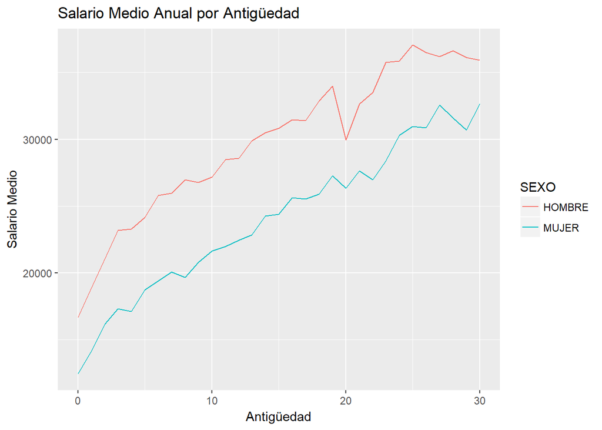

Analizamos las posibles diferencias según el tamaño del centro de trabajo de los asalariados.

```
##                        ESTRATO2 PROMEDIO_TOT PROMEDIO_H PROMEDIO_M
## 1 1. INCLUYE TODOS LOS ESTRATOS     21523.67   25066.22   17399.14
## 2     2.DE 1  A 49 TRABAJADORES     18831.01   21521.43   15577.12
## 3       5.INCLUYE ESTRATO 2 Y 3     25891.46   28672.60   21119.69
## 4    3.DE 50 A 199 TRABAJADORES     24369.96   27532.86   20755.62
## 5      4.200 Y MAS TRABAJADORES     28039.65   31914.78   24625.01
##   PORCENTAJE DIFERENCIA
## 1   69.41270   30.58730
## 2   72.37958   27.62042
## 3   73.65807   26.34193
## 4   75.38492   24.61508
## 5   77.15862   22.84138
```

Los centros de trabajo con más de 200 empleados son los que menor diferencia entre el sueldo medio anual entre géneros presentan.

Si estudiamos estos salarios medios según el convenio colectivo, sectorial de ámbito inferior es el que presenta mayores diferencias.

```
##                       REGULACION PROMEDIO_TOT PROMEDIO_H PROMEDIO_M
## 1   SECTORIAL DE AMBITO INFERIOR     19247.69   22076.09   16057.38
## 2              ESTATAL SECTORIAL     22896.27   26071.99   19670.72
## 3           DE CENTRO DE TRABAJO     26998.07   29725.55   22466.90
## 4 DE EMPRESA O GRUPO DE EMPRESAS     29001.62   32106.32   24696.18
## 5       OTRA FORMA DE REGULACIÓN     27465.08   29311.25   26145.04
##   PORCENTAJE DIFERENCIA
## 1   72.73652   27.26348
## 2   75.44773   24.55227
## 3   75.58111   24.41889
## 4   76.92000   23.08000
## 5   89.19797   10.80203
```

Por último, estudiamos los salarios medios por el tipo de mercado de destino de la empresa:

```
##            MERCADO PROMEDIO_TOT PROMEDIO_H PROMEDIO_M PORCENTAJE
## 1    UNION EUROPEA     25976.05   28584.13   21837.38   76.39688
## 2         NACIONAL     24411.19   27296.09   20950.58   76.75304
## 3          MUNDIAL     32312.10   35379.64   27159.00   76.76449
## 4 LOCAL O REGIONAL     19911.48   22006.72   17999.85   81.79252
##   DIFERENCIA
## 1   23.60312
## 2   23.24696
## 3   23.23551
## 4   18.20748
```

### CONCLUSIONES

[output not shown]